# wpbeginner

Domain Based Message Authentication Reporting (DMARC) email security protocol for Fortune 500, Global Top5k Companies and Government Domains

Author

LDVA

Published

December 16, 2022

# 1 Introduction

From the dmarc.org FAQ[^1]

> Email is easy to spoof and criminals have found spoofing to be a proven way to exploit user trust of well-known brands. Simply inserting the logo of a well known brand into an email gives it instant legitimacy with many users.

> Users can’t tell a real message from a fake one, and large mailbox providers have to make very difficult (and frequently incorrect) choices about which messages to deliver and which ones might harm users.

> DMARC is a way to make it easier for email senders and receivers to determine whether or not a given message is legitimately from the sender, and what to do if it isn’t. This makes it easier to identify spam and phishing messages, and keep them out of peoples’ inboxes.

## 1.2 Sample sizes

The Top5k companies dataset includes **109954** websites from **67** countries.

The Fortune 500 companies dataset includes **477** websites.

The government domains dataset includes **77051** websites from **198** countries.

### 1.2.1 DMARC

The proportions of domains with DMARC enabled vary widely.

Fortune 500 companies had the highest DMARC coverage (**0.79**), while government domains and top5k companies had a similarly low proportion of DMARC-enabled domains (**0.35** and **0.34** respectively).

In general, domains for F500 companies are twice as likely to have DMARC enabled as government or global top5k company domains.

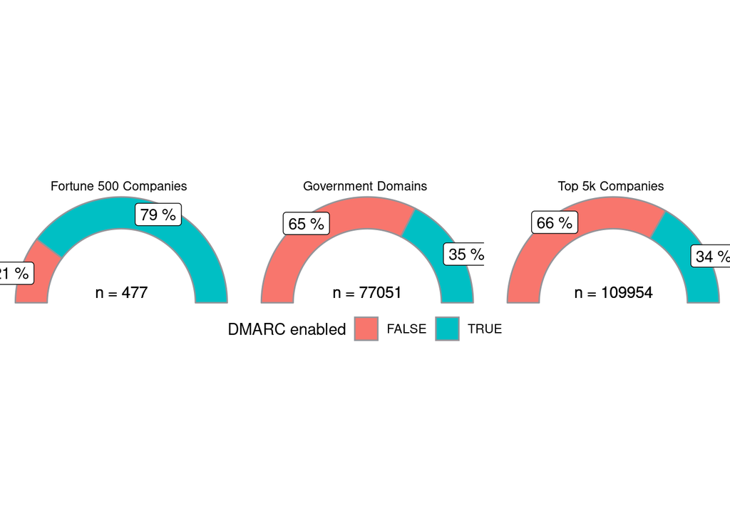

### 1.2.2 DMARC policies

Of the 379 Fortune 500 companies with DMARC enabled, almost half of them (47%) have the preferable policy of rejecting questionable messages. 14% are configured to quarantine these messages, but almost 40% have no DMARC policy set.

For Top5k companies with DMARC enabled (n=36879), 52% have no policy, 25% quarantine, and only 23% reject.

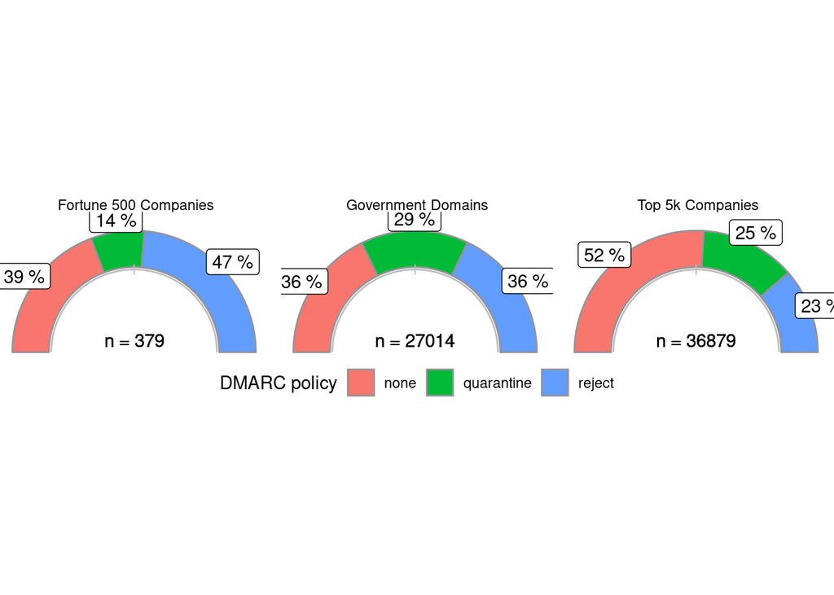

# 2 Top 5000 companies

## 2.1 By country - Top5k

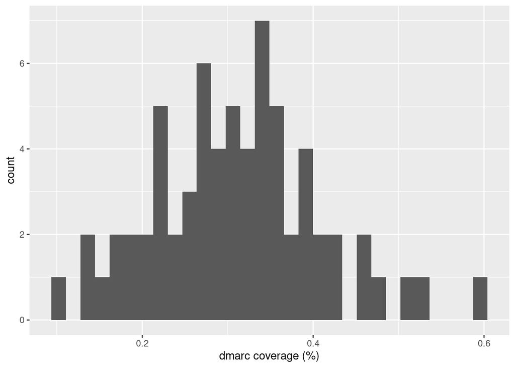

## 2.2 By Industry - Top5k

The Top5k Companies dataset includes **142** distinct industries, which vary in DMARC coverage and representation.

The proportion of domains with DMARC security varies by industry, from 8% (graphic design; n=45) to 59% (Banking, n=1241)

| industry | dmarc_valid | n | pct | n_ind |
| --- | --- | --- | --- | --- |
| banking | TRUE | 738 | 0.5946817 | 1241 |

| industry | dmarc_valid | n | pct | n_ind |
| --- | --- | --- | --- | --- |
| graphic design | TRUE | 4 | 0.08888889 | 45 |

Industries with varying online presence had wide variation in % DMARC tags.

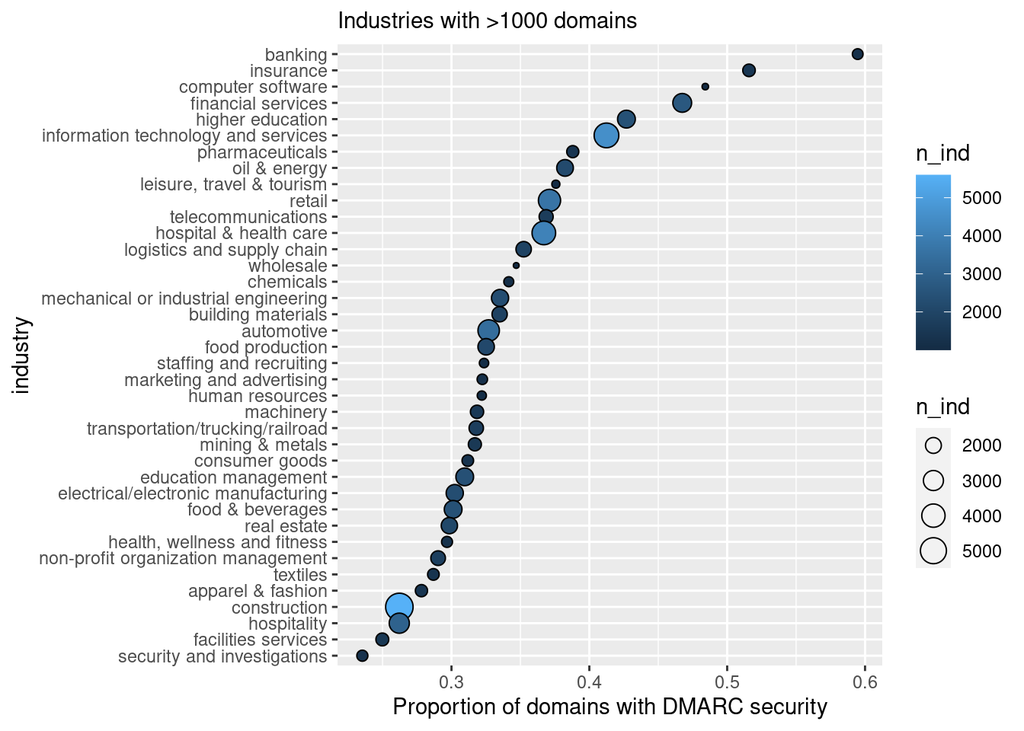

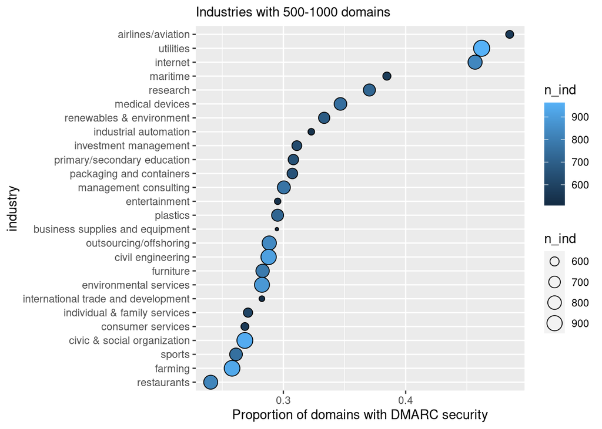

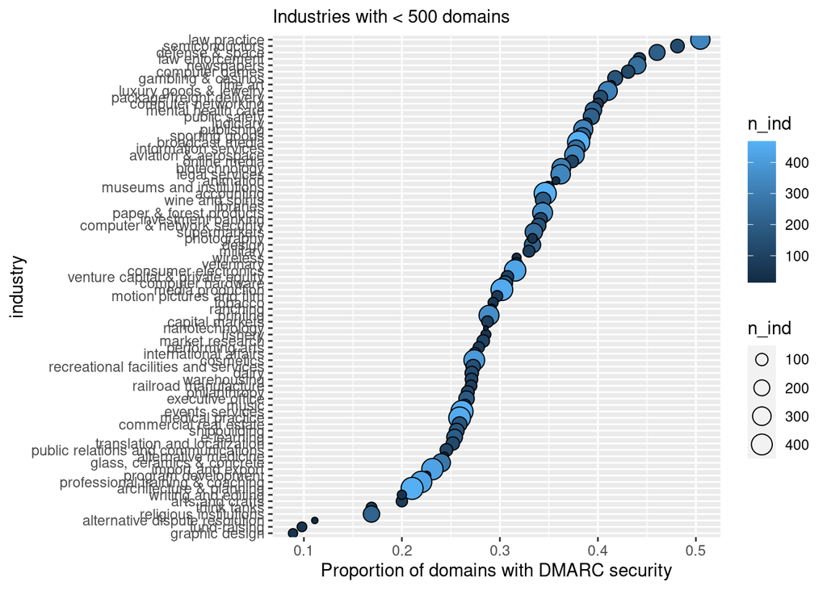

The web presence of a particular industry (number of domains) did not relate with the proportion of DMARC enabled domains.

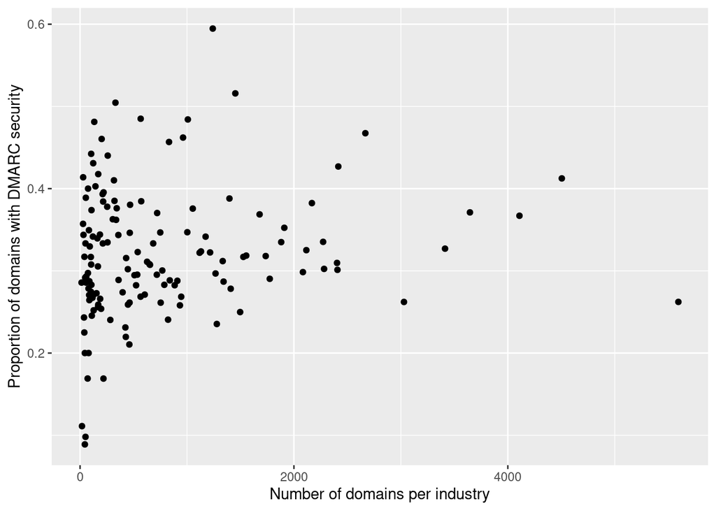

For 162 websites in the *Computer & network security* industry, only 33% had valid DMARC tags.

## 2.3 By Region - Top5k (UN regions)

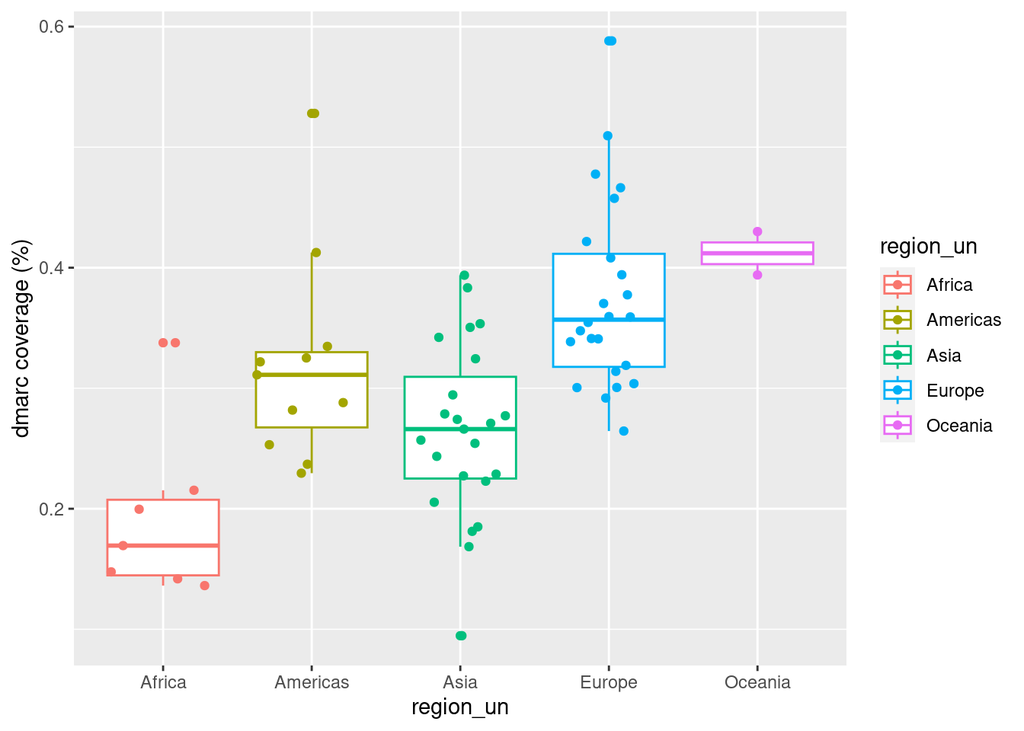

DMARC coverage (% enabled) varies within regions

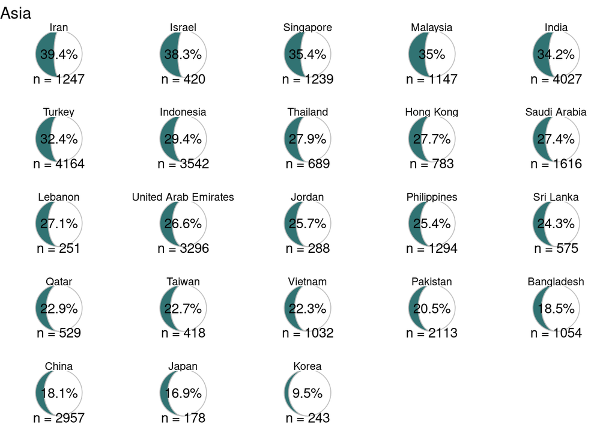

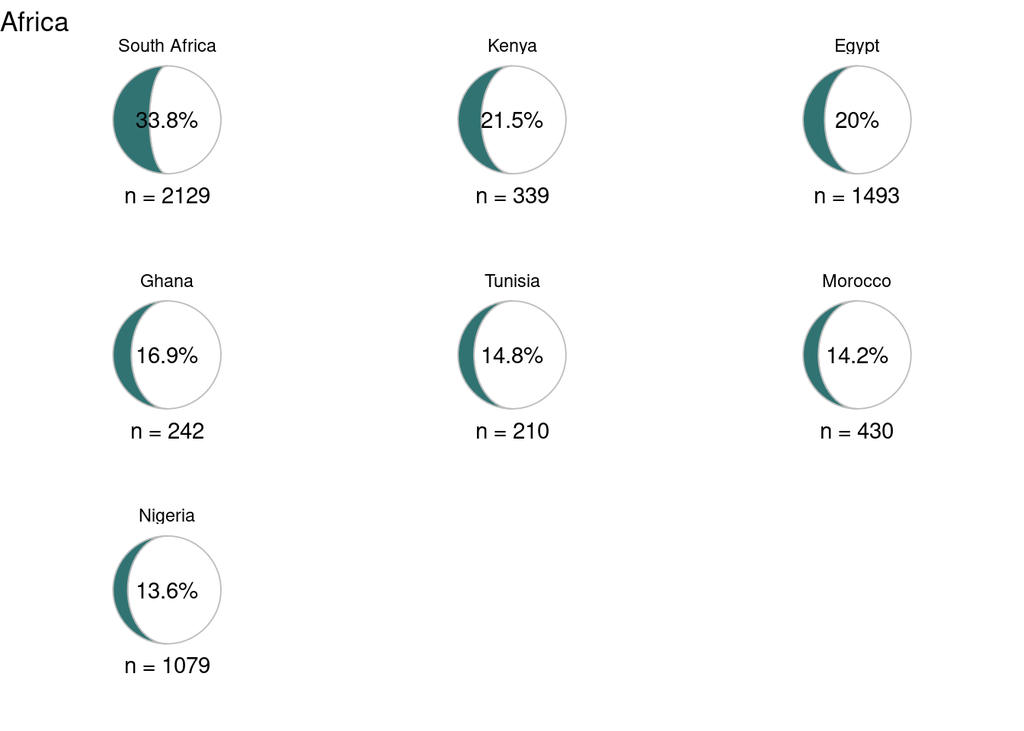

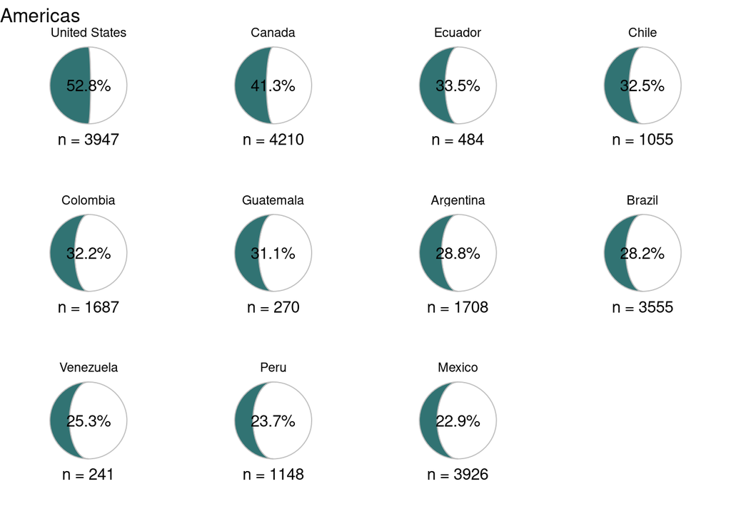

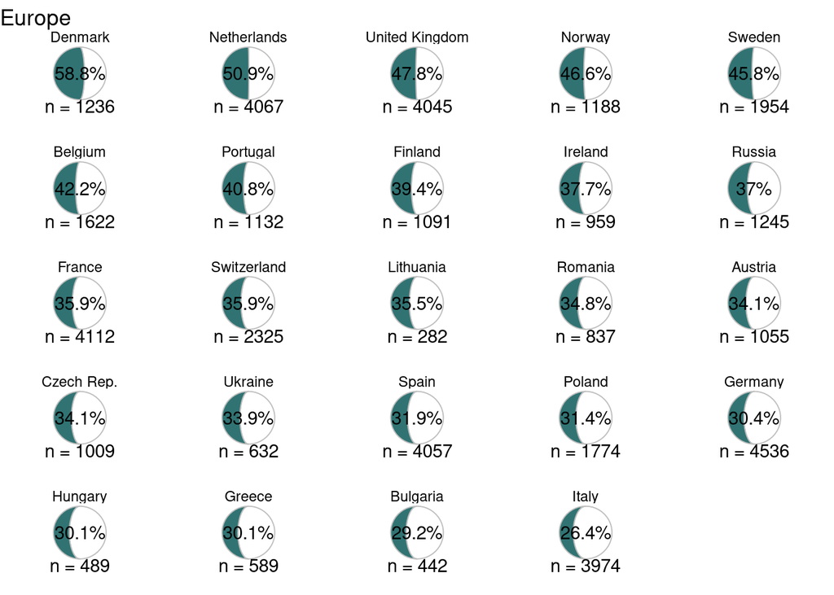

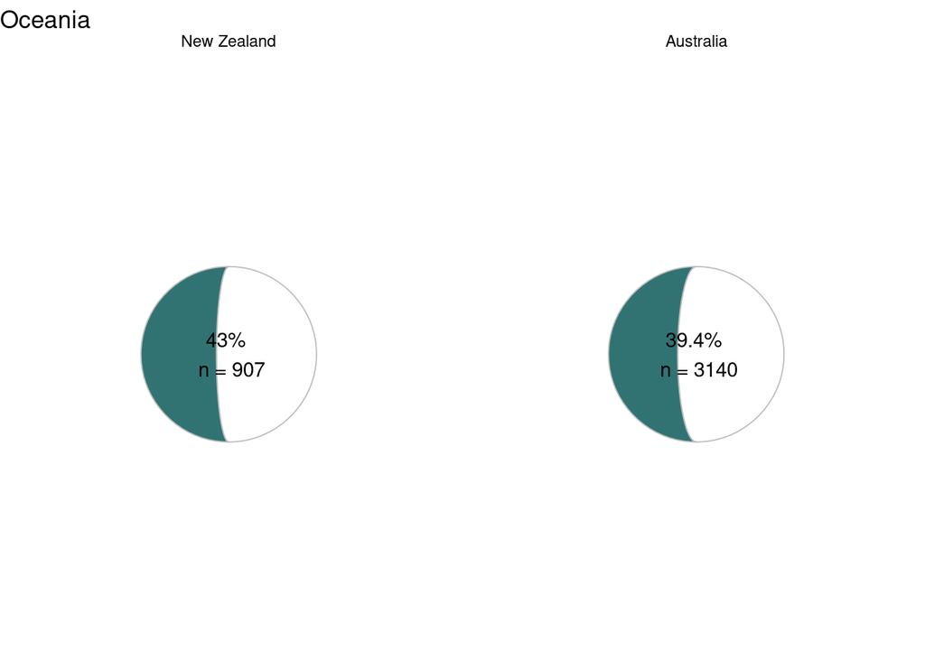

On a map:

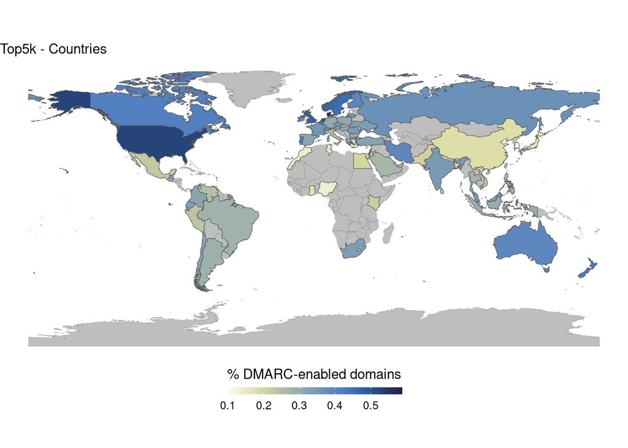

# 3 Government domains

The government domains dataset includes **77051** websites from **198** countries.

The countries with more entries in this dataset are USA and China.

| country | n_domains |
| --- | --- |
| United States of America (USA) | 21573 |
| China | 10930 |
| Indonesia | 7404 |
| Brazil | 3467 |
| India | 2377 |
| South Korea | 2322 |
| Vietnam | 2283 |
| Ukraine | 1449 |
| Malaysia | 1403 |
| Taiwan | 1351 |

[output cut: 10 more lines]

The countries with the fewest entries are Grenada and Suriname, and in total 18 countries have <= 5 domains in the dataset.

| country | n_domains |
| --- | --- |
| Grenada | 1 |
| Guinea-Bissau | 1 |
| Suriname | 1 |
| Equatorial Guinea | 2 |
| Nauru | 2 |
| Palau | 2 |
| Togo | 2 |
| Chad | 3 |
| Comoros | 3 |
| Marshall Islands | 3 |

[output cut: 8 more lines]

## 3.1 Subdomains

Of the total number of sites/urls, almost half of these entries represent subdomains within organizational domains.

Total sites: **77051**  
Organizational domains: **38978**

An organizational domain is the “root domain/top-level domain” of a domain name. That is, a domain name with all the subdomains removed[^2].

For example: *childsupport.ny.gov* and *senate.ny.gov* are both subdomains of the New York *.ny.gov* domain.

This is relevant for DMARC because policies can be inherited for subdomains but they can also be set flexibly and ‘adversaries can still deliver emails on behalf of a sites subdomains’[^3] if best practices are not followed.

Most organizational domains have few subdomains, but **5133** have >100 subdomains and “*jcy.gov.cn*” has **569** subdomains.

```
   Min. 1st Qu.  Median    Mean 3rd Qu.    Max.
   1.00    1.00    2.00   29.12   23.00  569.00
```

#### 3.1.0.1 Subdomain DMARC policies

```
[1] 91.5
```

```
 dmarc_tags_sp    n   percent
          none 6874 0.3998837
    quarantine 4493 0.2613729
        reject 5823 0.3387435
```

For websites with mismatched policies between organizational domains and subdomains, the most common subdomain policies were “none”, which is not ideal for avoiding impersonation.

| dmarc_tags_p_value | dmarc_tags_sp | n |
| --- | --- | --- |
| quarantine | none | 650 |
| reject | none | 362 |
| reject | quarantine | 151 |
| none | reject | 140 |
| none | quarantine | 104 |
| quarantine | reject | 62 |

## 3.2 By country - govt

| country | pct | n |
| --- | --- | --- |
| Armenia | 1.0000000 | 4 |
| Togo | 1.0000000 | 2 |
| Malta | 0.9655172 | 28 |
| Moldova | 0.9655172 | 84 |
| Switzerland | 0.9416058 | 129 |
| Hong Kong | 0.9266667 | 139 |
| Madagascar | 0.9090909 | 10 |
| Tanzania | 0.9075145 | 314 |
| Cameroon | 0.8888889 | 8 |
| Namibia | 0.8888889 | 8 |

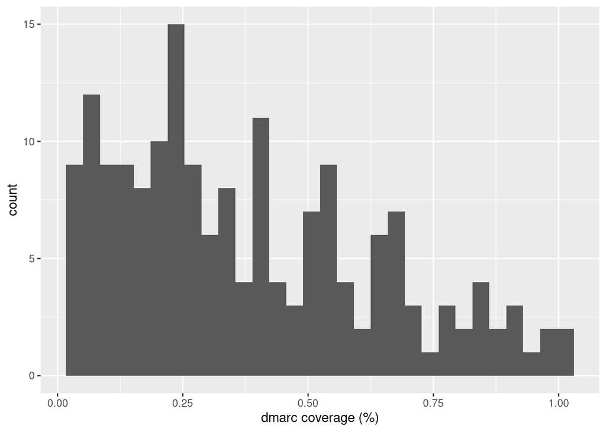

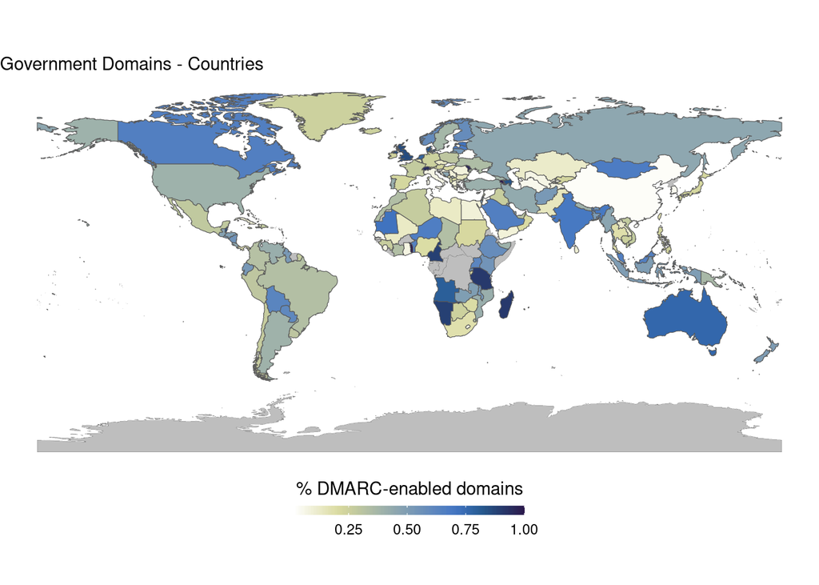

## 3.3 USA government domains

USA is the country with the most entries in the dataset (21573), and these data are more granular.

### 3.3.1 Level of government

A subset of **7802**, or **0.362**% of USA government domains has information about the level or type of government for a domain.

The levels included in the dataset are:

| govlevel |
| --- |
| Local Government |
| County Government |
| Federal Government |
| State Government |
| Native Sovereign Nation |
| Quasigovernmental |
| Regional |
| Level unclear, see note |

Local, County, and State Gov. are best represented.

| govlevel | n |
| --- | --- |
| Local Government | 5677 |
| County Government | 970 |
| State Government | 619 |
| Federal Government | 265 |
| Native Sovereign Nation | 167 |
| Quasigovernmental | 59 |
| Regional | 44 |

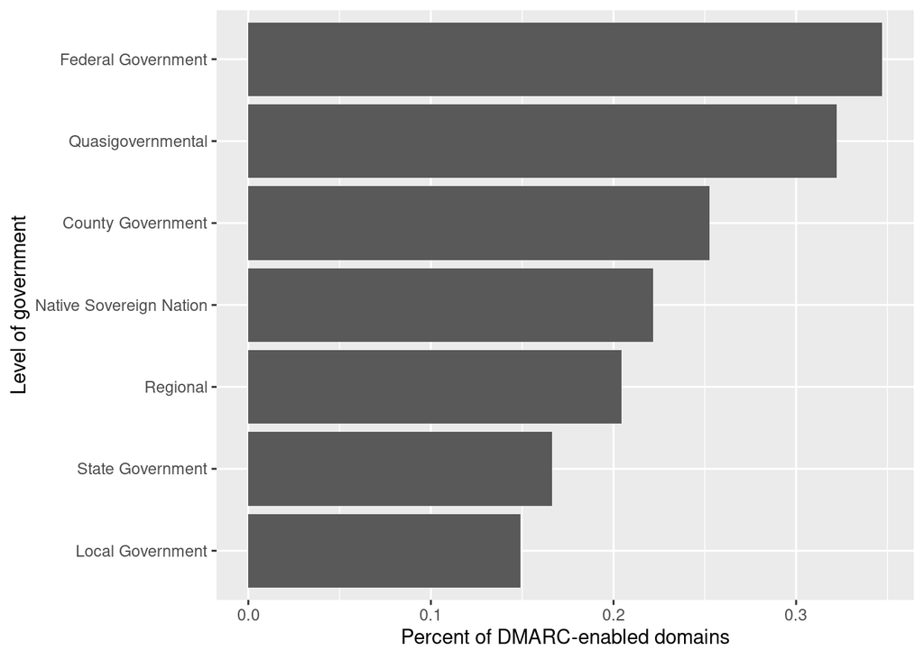

### 3.3.2 States

**13560**, or **62.9**% of USA government domains could be related with a US state or territory.

| statenew | n | percent |
| --- | --- | --- |
| New York | 818 | 0.06 |
| Wisconsin | 687 | 0.05 |
| District of Columbia | 619 | 0.05 |
| California | 590 | 0.04 |
| New Jersey | 565 | 0.04 |
| Texas | 563 | 0.04 |
| Pennsylvania | 551 | 0.04 |
| North Carolina | 481 | 0.04 |
| Minnesota | 468 | 0.03 |
| Florida | 464 | 0.03 |

[output cut: 52 more lines]

DMARC coverage varied across states and territories, and the highest values were in Washington DC and nearby states (Maryland, Virginia) where important government institutions and organizations are based.

| statenew | FALSE | TRUE | n | pctTrue |
| --- | --- | --- | --- | --- |
| District of Columbia | 122 | 497 | 619 | 0.8 |
| Maryland | 136 | 165 | 301 | 0.55 |
| Virginia | 236 | 128 | 364 | 0.35 |
| Colorado | 121 | 59 | 180 | 0.33 |
| Florida | 310 | 154 | 464 | 0.33 |
| Hawaii | 8 | 4 | 12 | 0.33 |
| California | 413 | 177 | 590 | 0.3 |
| Washington | 237 | 102 | 339 | 0.3 |
| Nevada | 44 | 17 | 61 | 0.28 |
| Alabama | 165 | 57 | 222 | 0.26 |

[output cut: 47 more lines]

## Footnotes

[^1]: https://dmarc.org/wiki/FAQ#Why_is_DMARC_important.3F
[^2]: https://dmarcly.com/blog/how-dmarc-works-with-subdomains-dmarc-sp-tag
[^3]: https://dmarcly.com/blog/how-dmarc-works-with-subdomains-dmarc-sp-tag